# tealeaves: Intermediate Users

Chris Mur

2022-07-19

```r
# install tidyverse packages if necessary
# install.packages("tidyverse")

library(dplyr)
library(ggplot2)
library(magrittr)
library(tealeaves)

# Parameter sets ----

cs <- tealeaves::make_constants()
lp <- tealeaves::make_leafpar(
  replace = list(
    # Hypo- and amphistomatous leaves
    logit_sr = set_units(c(-Inf, 0))
  )
)
ep <- tealeaves::make_enviropar(
  replace = list(
    # Low and high light
    S_sw = set_units(c(220, 660), "W/m^2"),
    # Air temperature gradient
    T_air = set_units(seq(278.15, 313.15, length.out = 25), "K")
    )
)

# Run tleaves ----
tl_example1 <- tleaves(lp, ep, cs)

usethis::use_data(tl_example1)
```

Next, we’ll usee **ggplot2** to plot the leaf-to-air temperature difference as function of air temperature at the two light levels.

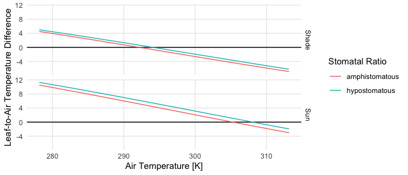

The results show that leaves are warmer than the atmosphere at cool temperatures and cooler at high temperatures. In sunnier conditions, leaves are warmer. Finally, amphistomatous leaves are somewhat cooler because they evaporate more water. To see this, let’s look directly at transpiration in the same data:

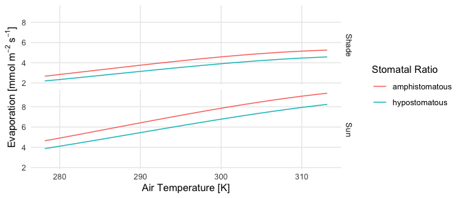

[^1]: The ’unit’ed version ensures that all calculations start and end with the proper units. The unitless functions *should* give the same answer because I run tests every time the package is updated, but it’s always good to double check for bugs.